# 18126_MY461_Final

18126

09/04/2019

##### Checks

getwd() setwd(“/Users/davidebestagno/Documents/University/LSE/MY461/”)

## Set up and data

```r
#libary used
library(igraph)
#data
bill_data <- read.csv("110_billspon.csv", header = T, row.names = "X", as.is = T)
sen_data <- read.csv("110_sen.csv", header = T, row.names = "Name", as.is = T)
#for bill the column names are the names of the senators and the row names are the Bills
#for sen the column names are the chracteristics of the senators and the row names are the names of the senators
```

## Bill network & complete network

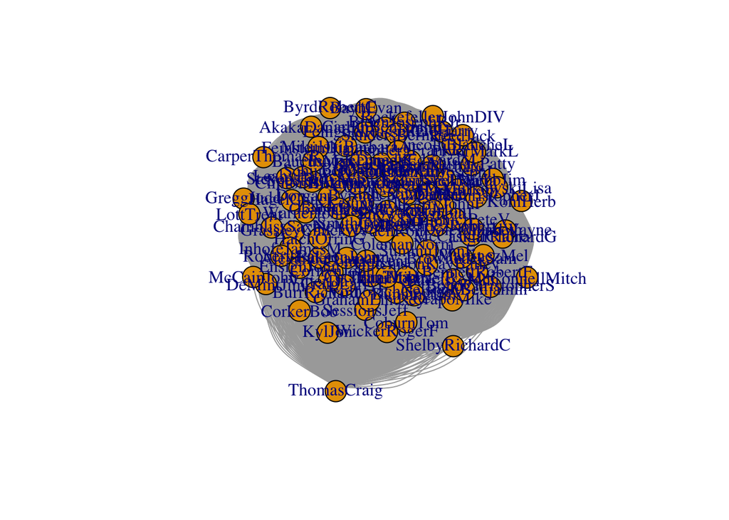

```r
edge_list <- c()

for (r in 1:nrow(bill_data))
  {#this is a loop for every row of a dataframe
  list_row <- c()
  draft_edge_list <- c()
  i <- 1
  p <- 1
  for (c in 1:ncol(bill_data))
    { # this is a for loop for every obervations in a row
    if(bill_data[r,c] != 0)
      {
      list_row[[i]] <- colnames(bill_data)[c]
      i <- i+1
      }
    }

  if(length(list_row) > 1)
    {

    for (i in 1:ncol(combn(list_row,2)))
      {
      draft_edge_list[[p]] <- combn(list_row,2)[1,i]
      p <- p+1
      draft_edge_list[[p]] <- combn(list_row,2)[2,i]
      p <- p+1
      }
    }
  edge_list <- append(edge_list, draft_edge_list)
}

bill <- graph(edges=edge_list, directed = F)#bill network with no weigths
adj_bill <- get.adjacency(bill) #adjeciency matrix
plot(bill)
```

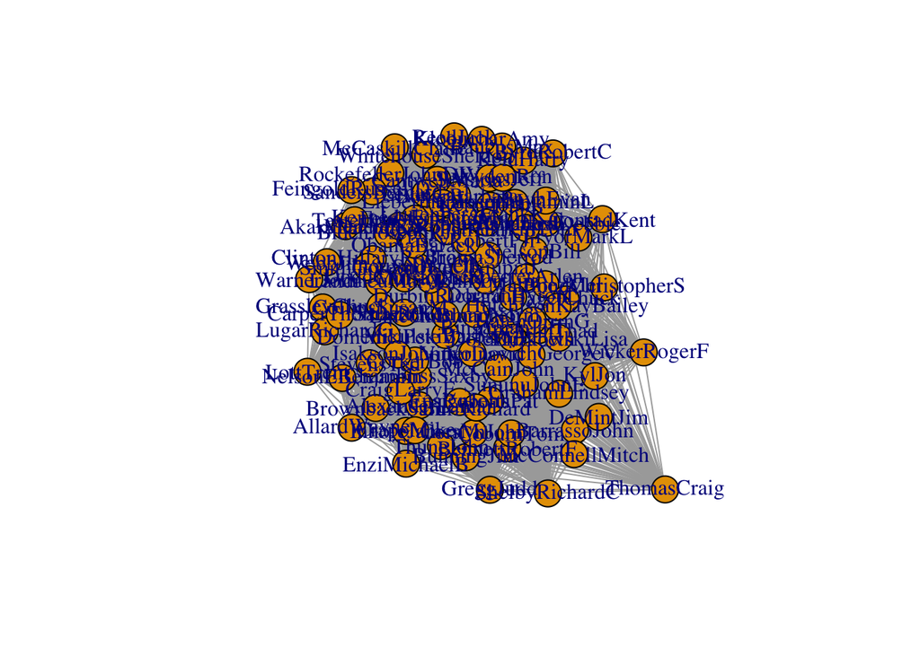

```r
complete <- graph.adjacency(adj_bill, mode="undirected", weighted=T) #bill network with weights
adj_complete <- get.adjacency(complete) #adjecicency matrix
plot(complete)
```

```r
summary(complete)
```

```
## IGRAPH 88214d8 UNW- 102 5151 --
## + attr: name (v/c), weight (e/n)
```

```r
summary(bill)
```

```
## IGRAPH e68740b UN-- 102 446723 --
## + attr: name (v/c)
```

##### Adding metadata to the bill and complete network

```r
V(bill)$Party <- sen_data$Party
V(bill)$Gender <- sen_data$Gender
V(bill)$Religion <- sen_data$Religion
V(bill)$Class <- sen_data$Class
V(bill)$State <- sen_data$State
V(bill)$CensusRegion <- sen_data$CensusRegion
V(bill)$PriorExperience <- sen_data$PriorExperience
V(bill)$Education <- sen_data$Education
V(bill)$FirstTookOffice <- sen_data$FirstTookOffice
V(bill)$Born <- sen_data$Born
#get.vertex.attribute(bill)

V(complete)$Party <- sen_data$Party
V(complete)$Gender <- sen_data$Gender
V(complete)$Religion <- sen_data$Religion
V(complete)$Class <- sen_data$Class
V(complete)$State <- sen_data$State
V(complete)$CensusRegion <- sen_data$CensusRegion
V(complete)$PriorExperience <- sen_data$PriorExperience
V(complete)$Education <- sen_data$Education
V(complete)$FirstTookOffice <- sen_data$FirstTookOffice
V(complete)$Born <- sen_data$Born
```

##### Summary and quartiles

```r
summary(complete)
```

```
## IGRAPH 88214d8 UNW- 102 5151 --
## + attr: name (v/c), Party (v/c), Gender (v/c), Religion (v/c),
## | Class (v/n), State (v/c), CensusRegion (v/n), PriorExperience
## | (v/c), Education (v/c), FirstTookOffice (v/n), Born (v/n),
## | weight (e/n)
```

```r
summary(bill)
```

```
## IGRAPH e68740b UN-- 102 446723 --
## + attr: name (v/c), Party (v/c), Gender (v/c), Religion (v/c),
## | Class (v/n), State (v/c), CensusRegion (v/n), PriorExperience
## | (v/c), Education (v/c), FirstTookOffice (v/n), Born (v/n)
```

```r
#nb there are 102 senators instead than the usual 100 because one died (Craig Thomas replaced by John Barrasso) and one resigned (Trent Lott replaced by Roger Wicker).
lwr_bill <- adj_bill[lower.tri(adj_bill, diag = F)]
```

```
## <sparse>[ <logic> ] : .M.sub.i.logical() maybe inefficient
```

```r
quantile(lwr_bill)
```

```
##   0%  25%  50%  75% 100%
##    3   53   73  103  423
```

103 is the cut off for the upper quartile

## Simple network (only eedges between nodes with more than 103 bills cosponsored)

```r
adj_bill[adj_bill < 103] <- 0
#changing of values on the adjeciency matrix of the complete network to 0 if lower than 103 creates the adjeciency matrix for the simple network
simple <- graph.adjacency(adj_bill, mode="undirected", weighted = T)

#adding metadata
V(simple)$Party <- sen_data$Party
V(simple)$Gender <- sen_data$Gender
V(simple)$Religion <- sen_data$Religion
V(simple)$Class <- sen_data$Class
V(simple)$State <- sen_data$State
V(simple)$CensusRegion <- sen_data$CensusRegion
V(simple)$PriorExperience <- sen_data$PriorExperience
V(simple)$Education <- sen_data$Education
V(simple)$FirstTookOffice <- sen_data$FirstTookOffice
V(simple)$Born <- sen_data$Born

#Summary and plot
summary(simple)
```

```
## IGRAPH 51a25b4 UNW- 102 1305 --
## + attr: name (v/c), Party (v/c), Gender (v/c), Religion (v/c),
## | Class (v/n), State (v/c), CensusRegion (v/n), PriorExperience
## | (v/c), Education (v/c), FirstTookOffice (v/n), Born (v/n),
## | weight (e/n)
```

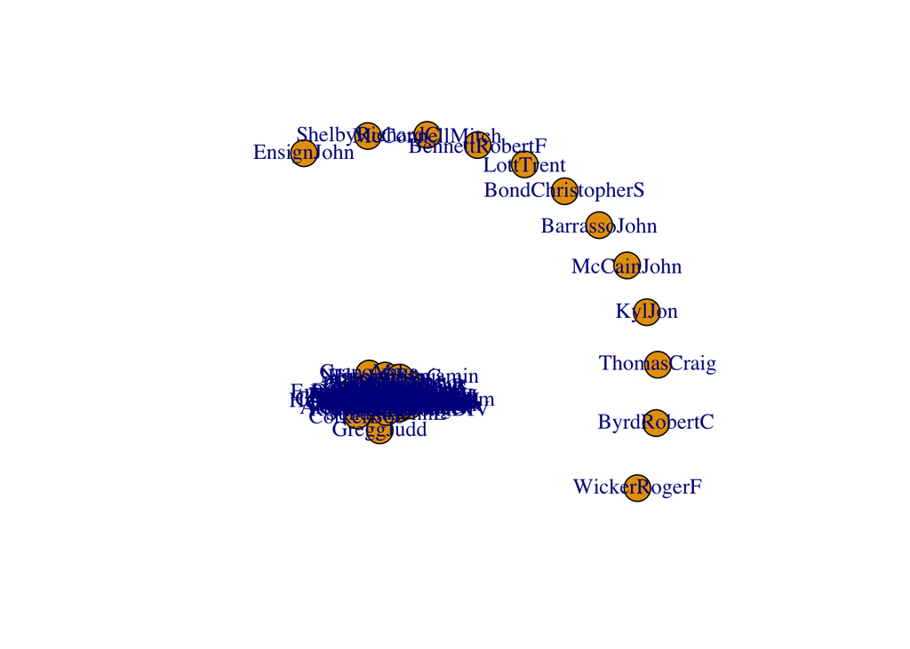

```r
plot(simple)
```

## Question 1

Consider the overall metrics (density, average path length, transitivity) of both the full and the simplified networks. How do the two networks compare to each other? Compare the simplified network to random networks created with the Erdős–Rényi and the configuration models. What do these comparisons tell you about the nature and structure of the relationships among the senators? In your answer, make sure to define each of the metrics and give an intuitive interpretation for them.

```r
totd <- degree(simple, mode='all')
#Since Erdős–Rényi is a randomly generated, I am avereging the result over 100 instances
GNP <- lapply(rep(1, 100), function(x)
  sample_gnp(102, mean(totd)/101))
GNP_d <- sapply(GNP, graph.density)
GNP_a <- sapply(GNP, average.path.length)
GNP_t <- sapply(GNP, transitivity)


outd <- degree(simple, mode = "out")
ind <- degree(simple, mode = "in")

#Since the Configuration model is randomly generated, I am avereging the result over 100 intances
Conf <- lapply(rep(1, 100), function(x)
  sample_degseq(out.deg = outd, in.deg = ind, method = "simple"))
Conf_d <- sapply(Conf, graph.density)
Conf_a <- sapply(Conf, average.path.length)
Conf_t <- sapply(Conf, transitivity)

#result table
res_table <- data.frame(c('Complete', 'Simple','Erdos-Renyi', 'Configuration'),
                        c(graph.density(complete), graph.density(simple), mean(GNP_d), mean(Conf_d)),
                        c(average.path.length(complete), average.path.length(simple), mean(GNP_a), mean(Conf_a)),
                        c(transitivity(complete), transitivity(simple), mean(GNP_t), mean(Conf_t)))
colnames(res_table) <- c('Model','Density', 'Average path length', 'Transitivity')
res_table
```

```
##           Model   Density Average path length Transitivity
## 1      Complete 1.0000000            1.000000    1.0000000
## 2        Simple 0.2533489            1.859675    0.7622924
## 3   Erdos-Renyi 0.2532091            1.747698    0.2529238
## 4 Configuration 0.2533489            1.916478    0.6159937
```

Density is defined as the the ratio of the number of edges and the number of possible edges in a network. The formula to calculate the density of a graph is:

$$density = \frac{e}{v(v-1)/2}$$
[^1] [^1]: Where $e$ is the number of edges and $v$ is the number of vertices (Scott,2017, p.82).

This concept was first used in Social Network Analysis by Clyde Mitchell, and he interpreted it as the as the completness of the network (Scott 2017, p.33). Usually, social networks with higher density tend to represent a more closely knit community (Wellman 1979, p.1217).[^1]

Average path length on the other hand is defined as the average of the geodesic distance between two nodes, for all nodes in a network. In an undirected network the formula for the average path length is:

$$L = \frac{1}{\frac{v(v-1)}{2}}\sum_{i,j}{l_{i,j}}$$
[^3] [^3]: Where $l_{i,j}$ is the geodesic distance between nodes $i$and $j$.

This metric can be used a a proxy to measure of how fast information can pass across the whole network. For instance, if the average path length is very low, it means that the network is well connected and information can take be spread quickly throughout the network.

Lastly, transitivity (sometimes called clustering coefficient) measures the probability that the neighbours of a node are themselves connected.

$$transitivity = \frac{1}{n}\sum^{n}_{i}{\frac{e_i}{\frac{d_i(d_{i}-1)}{2}}}$$
[^4] [^4]: Where $d_i$ is the degree of the node $i$ and $e_i$ is the number of edges between the neighbours of node i.

High levels of transitivity indicate greater clustering, something usually found in real social network rather than in randomly generated ones.

The complete network has all the previously defined metrics equal to 1. This means that the network has all possible edges, the geodesic path for any couple of nodes is a single edge , and for every nodes all the neighbours are connected between each other. In other words the graph is complete.

The simple network, instead, has features more similar to the ones produced by the small world experiment, which are relatively low average path lenght and high transitivity (Travers and Milgram 1969).

The difference between the complete network and the simple network is probably due to the fact that often the bills have dozens of cosponsors, hence it is likely for senators to have at least one cosponsored bill in common with any other senator in a two year period. However, they cetrainly have have much stronger relations with other specific senator probably due to being in the same party, or closer in terms of political ideologies. As a consequnce, when we look only at the strongest relations between senators, there are fewer edges, which causes the lower density and transitivity and increases the path lenght.[^2]

When trying to simulate the simple netwrok, the Erdős–Rényi and Configuration are both extremely accurate for the density and the path lenght. However, They are both quite far away from the transitivity value of the simple model. The configuration model is definitely much closer than the Erdös-Rényi, probably due to the fact that the configuration model mantains the exact degree distribution of the simple network for each node (in fact the density value is exaclty the same). Instead the Erdös-Rènyi model is randomly generated following a predefined probability.

## Question 2

Who do you see as the most influential senators in the 110th Congress? Identify two potential meanings of “influence,” as proxied by different centrality measures. Justify your choice of each centrality measure. In that justification, present clear interpretations of what each centrality measure is capturing about the position of senators. For each of your chosen centrality measures, identify the senator who has the highest value in the simplified network. Discuss why you think that senator is the most central in the network. Make explicit reference in your response to the concepts of social capital and brokerage/structural holes covered in the course material. [Note that if you use edge weight for a centrality measure, you need to identify how the calculation interprets those weights (i.e., do higher values mean greater closeness or greater distance?); in those cases where the measure assumes that higher values means greater distance, you should use 1/weight in the calculation.]

```r
#Degree Centrality
deg <- degree(complete)
(idx <- which(degree(complete)==max(degree(complete))) )
```

```
##       AlexanderLamar          AllardWayne         BarrassoJohn
##                    1                    2                    3
##       BennettRobertF           BunningJim       ChamblissSaxby
##                    4                    5                    6
##            CoburnTom          CochranThad          ColemanNorm
##                    7                    8                    9
##            CorkerBob           CornynJohn          CraigLarryE
##                   10                   11                   12
##            CrapoMike            DeMintJim        DomeniciPeteV
##                   13                   14                   15
##           EnsignJohn         EnziMichaelB      FeinsteinDianne
##                   16                   17                   18
##        GrassleyChuck            GreggJudd          HatchOrrinG
##                   19                   20                   21
##         InhofeJamesM        IsaksonJohnny               KylJon
##                   22                   23                   24
##            LottTrent          MartinezMel           McCainJohn
##                   25                   26                   27
##       McConnellMitch           RobertsPat         SessionsJeff
##                   28                   29                   30
##         SpecterArlen           StevensTed          VitterDavid
##                   31                   32                   33
##           WarnerJohn            BaucusMax       BidenJosephRJr
##                   34                   35                   36
##         BoxerBarbara         BrownSherrod          ByrdRobertC
##                   37                   38                   39
##        CantwellMaria      CardinBenjaminL       CaseyRobertPJr
##                   40                   41                   42
## ClintonHillaryRodham     DoddChristopherJ        DurbinRichard
##                   43                   44                   45
##       KennedyEdwardM           KerryJohnF        LandrieuMaryL
##                   46                   47                   48
##        LeahyPatrickJ            LevinCarl     LiebermanJosephI
##                   49                   50                   51
##        LugarRichardG       MenendezRobert     MikulskiBarbaraA
##                   52                   53                   54
##            ReidHarry   RockefellerJohnDIV       SandersBernard
##                   55                   56                   57
##      SchumerCharlesE       StabenowDebbie     VoinovichGeorgeV
##                   58                   59                   60
```

[output cut: 13 more lines]

```
##                   79                   80                   81
##         KlobucharAmy      McCaskillClaire             ReedJack
##                   82                   83                   84
##             WydenRon       ShelbyRichardC        InouyeDanielK
##                   85                   86                   87
##          ObamaBarack        DoleElizabeth           ConradKent
##                   88                   89                   90
##           JohnsonTim            TesterJon          SununuJohnE
##                   91                   92                   93
##   HutchisonKayBailey         SmithGordonH             BayhEvan
##                   94                   95                   96
##        MurkowskiLisa     BondChristopherS        CarperThomasR
##                   97                   98                   99
##           PryorMarkL          ThomasCraig         WickerRogerF
##                  100                  101                  102
```

```r
V(complete)$vertex.names[idx]
```

```r
summary(deg)
```

```
##    Min. 1st Qu.  Median    Mean 3rd Qu.    Max.
##     101     101     101     101     101     101
```

```r
deg <- degree(bill)
(idx <- which(degree(bill)==max(degree(bill))) )
```

```
## KerryJohnF
##         47
```

```r
V(bill)$vertex.names[idx]
```

```r
summary(deg) #using bill J kerry has the highest, so there might be a way to treat weights.
```

```
##    Min. 1st Qu.  Median    Mean 3rd Qu.    Max.
##    1728    6587    8144    8759   11010   15891
```

```r
#This doesn't tell me anything because they are all connected so they all have the same degree

#Eigenvector Centrality
eig <- evcent(complete)$vector
(idx <- which(evcent(complete)$vector==max(evcent(complete)$vector)) )
```

```
## ClintonHillaryRodham
##                   43
```

```r
V(complete)$vertex.names[idx]
```

```r
summary(eig)
```

```
##    Min. 1st Qu.  Median    Mean 3rd Qu.    Max.
## 0.08577 0.36096 0.46912 0.51059 0.67926 1.00000
```

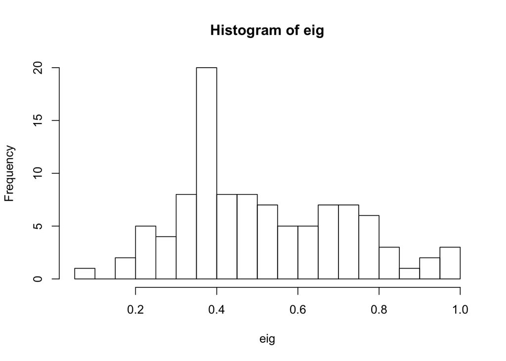

```r
hist(eig,breaks=20)
```

```r
#Hilary clinton has the higehst eigenvector centrality

#Pagerank centrality
pr <- page.rank(complete)$vector
(idx <- which(page.rank(complete)$vector==max(page.rank(complete)$vector)))
```

```
## KerryJohnF
##         47
```

```r
V(complete)$vertex.names[idx]
```

```r
summary(pr)
```

```
##     Min.  1st Qu.   Median     Mean  3rd Qu.     Max.
## 0.003154 0.007776 0.009284 0.009804 0.011865 0.016373
```

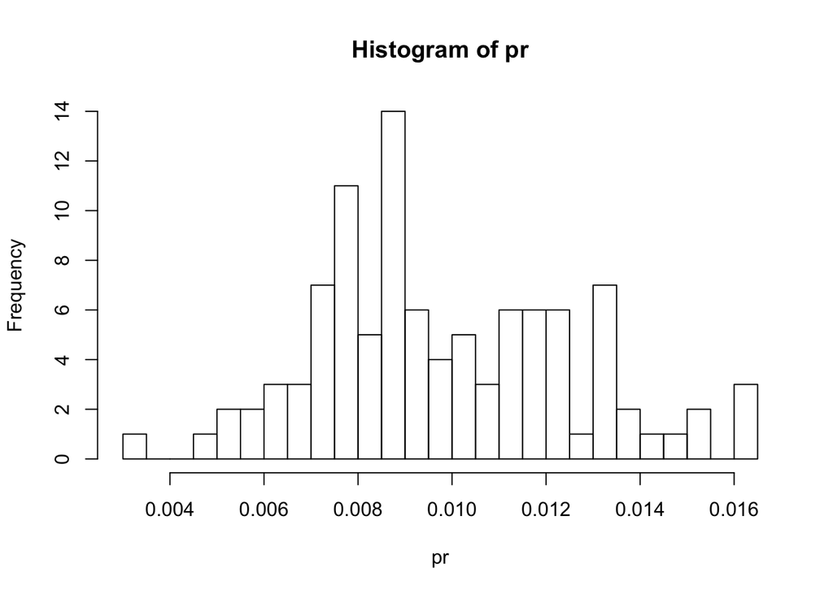

```r
hist(pr,breaks=20)
```

```r
#John Kerry has the highest page rank centrality

#Closeness Centrality
clo <- closeness(complete)
(idx <- which(closeness(complete)==max(closeness(complete))) )
```

```
## ThomasCraig
##         101
```

```r
V(complete)$vertex.names[idx]
```

```r
summary(clo)
```

```
##      Min.   1st Qu.    Median      Mean   3rd Qu.      Max.
## 0.0001759 0.0002617 0.0003104 0.0003053 0.0003422 0.0005800
```

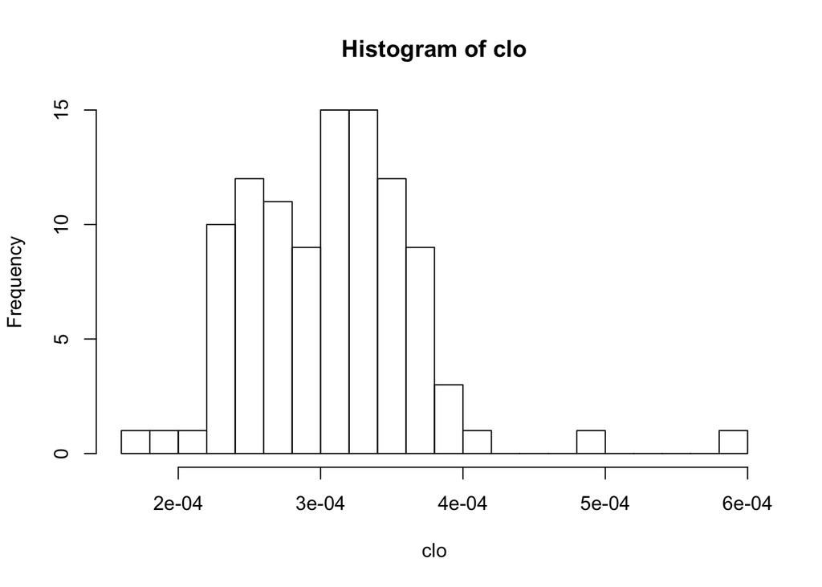

```r
hist(clo,breaks=20)
```

```r
#hist(clo[clo>0.00005],breaks=20)
#ThomasCraig has the highest but nb very small values

#Betweenness Centrality
bet <- betweenness(complete)
(idx <- which(betweenness(complete)==max(betweenness(complete))) )
```

```
## ThomasCraig
##         101
```

```r
V(complete)$vertex.names[idx]
```

```r
summary(bet)
```

```
##    Min. 1st Qu.  Median    Mean 3rd Qu.    Max.
##    0.00    0.00    0.00   48.39    0.00 4836.00
```

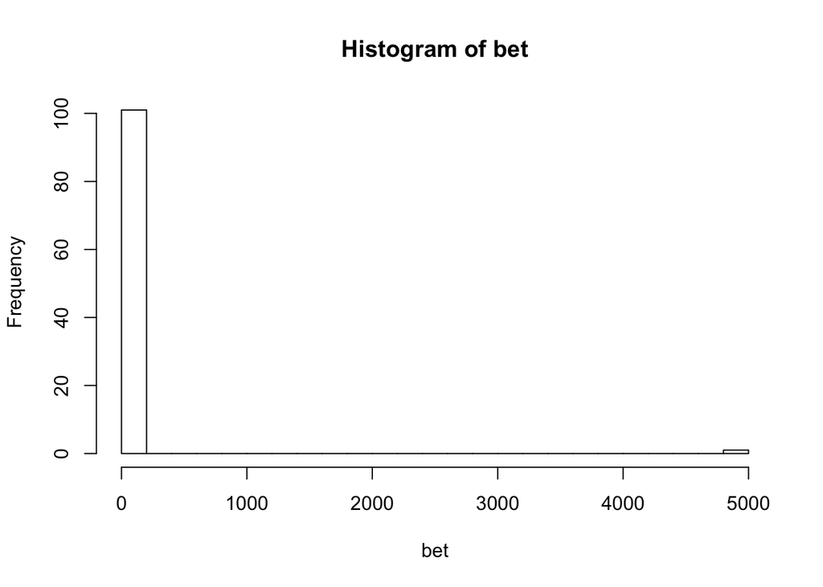

```r
hist(bet,breaks=20) #this graph looks weirdly binomial b/c T. Craig has crazy high betweeness centrality. Does that mean he is a crazy broker between two side of the spectrum? but how is that possible if everyone is connected to everyone else, there shouldn't be someone with such a strong broker position. There is something wrong here imho. How is betweeness calculated. Could this be the guys that need 1/weight?
```

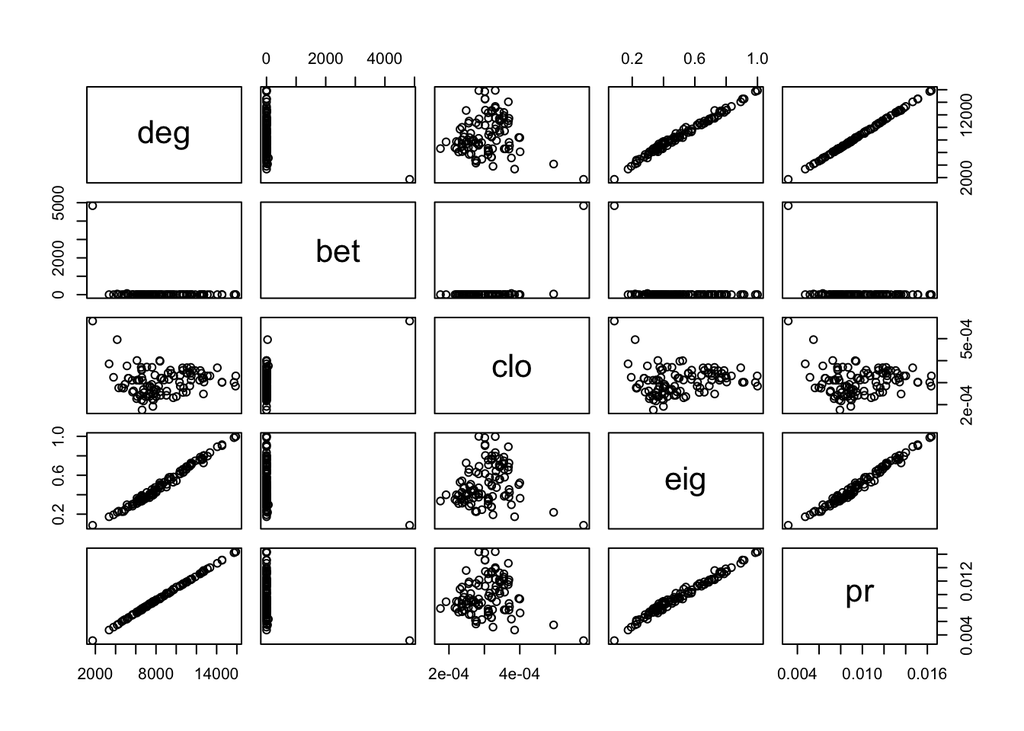

```r
#In a data frame
cents<- data.frame(deg, bet, clo, eig, pr)
plot(cents)
```

```r
cor(cents)
```

```
##              deg        bet          clo         eig          pr
## deg  1.000000000 -0.2403292  0.002791604  0.99360870  0.99971387
## bet -0.240329235  1.0000000  0.464517415 -0.21077271 -0.24631194
## clo  0.002791604  0.4645174  1.000000000  0.09558706 -0.01721977
## eig  0.993608695 -0.2107727  0.095587065  1.00000000  0.99063219
## pr   0.999713873 -0.2463119 -0.017219765  0.99063219  1.00000000
```

## Question 3

How does political party membership influence bill co-sponsorship? Calculate the assortativity by political party and the probability of a co-sponsorship tie within and between each party (using a blockmodel approach) for the simplified network. Run the Louvain community detection algorithm on the full network and see how the resulting communities align (or not) with political party. Plot the full network twice (with the same layout) with nodes coloured by (1) the results of the community detection algorithm and (2) the vertex attribute which you identify as most closely aligning with the resulting communities (include a figure label). Discuss what the results of these analyses imply about the political parties at this time.

## Question 4

Do different senators seem to fulfil different roles in the senate? Evaluate the structural equivalency of the senators in the full network and use this to divide the senators into four equivalency classes. Interpret the four groups identified, drawing on information regarding party and leadership. Discuss what this implies about the senators, drawing on the concepts of position and role.

```r
adj_complete
```

[output not shown]

[output not shown]

[output not shown]

[output cut: 357 more lines]

[output not shown]

## Question 5

[^1]: For instance, Barry Wellman’s study of inner city suburb showed that the densest network where the one composed mainly by members of the same kin.
[^2]: It could be interesting to see if the party homophily for the simple network is higher than for the complete network which would prove that the stronger relations are divided across party lines.